# ASSIGNMENT_4.

Pjeanjud

2026-10-24

```r
pharma <- read.csv("Pharmaceuticals.csv")
names(pharma)
```

```
##  [1] "Symbol"                "Name"                  "Market_Cap"
##  [4] "Beta"                  "PE_Ratio"              "ROE"
##  [7] "ROA"                   "Asset_Turnover"        "Leverage"
## [10] "Rev_Growth"            "Net_Profit_Margin"     "Median_Recommendation"
## [13] "Location"              "Exchange"
```

```r
head(pharma)
```

```
##   Symbol                Name Market_Cap Beta PE_Ratio  ROE  ROA Asset_Turnover
## 1    ABT Abbott Laboratories      68.44 0.32     24.7 26.4 11.8            0.7
## 2    AGN      Allergan, Inc.       7.58 0.41     82.5 12.9  5.5            0.9
## 3    AHM        Amersham plc       6.30 0.46     20.7 14.9  7.8            0.9
## 4    AZN     AstraZeneca PLC      67.63 0.52     21.5 27.4 15.4            0.9
## 5    AVE             Aventis      47.16 0.32     20.1 21.8  7.5            0.6
## 6    BAY            Bayer AG      16.90 1.11     27.9  3.9  1.4            0.6
##   Leverage Rev_Growth Net_Profit_Margin Median_Recommendation Location Exchange
## 1     0.42       7.54              16.1          Moderate Buy       US     NYSE
## 2     0.60       9.16               5.5          Moderate Buy   CANADA     NYSE
## 3     0.27       7.05              11.2            Strong Buy       UK     NYSE
## 4     0.00      15.00              18.0         Moderate Sell       UK     NYSE
## 5     0.34      26.81              12.9          Moderate Buy   FRANCE     NYSE
## 6     0.00      -3.17               2.6                  Hold  GERMANY     NYSE
```

```r
# variables 1-9

pharma_num <- pharma[, 3:11]
head(pharma_num)
```

```
##   Market_Cap Beta PE_Ratio  ROE  ROA Asset_Turnover Leverage Rev_Growth
## 1      68.44 0.32     24.7 26.4 11.8            0.7     0.42       7.54
## 2       7.58 0.41     82.5 12.9  5.5            0.9     0.60       9.16
## 3       6.30 0.46     20.7 14.9  7.8            0.9     0.27       7.05
## 4      67.63 0.52     21.5 27.4 15.4            0.9     0.00      15.00
## 5      47.16 0.32     20.1 21.8  7.5            0.6     0.34      26.81
## 6      16.90 1.11     27.9  3.9  1.4            0.6     0.00      -3.17
##   Net_Profit_Margin
## 1              16.1
## 2               5.5
## 3              11.2
## 4              18.0
## 5              12.9
## 6               2.6
```

```r
# Normalize
pharma_scaled <- scale(pharma_num)
head(pharma_scaled)
```

```
##      Market_Cap        Beta    PE_Ratio         ROE        ROA Asset_Turnover
## [1,]  0.1840960 -0.80125356 -0.04671323  0.04009035  0.2416121      0.0000000
## [2,] -0.8544181 -0.45070513  3.49706911 -0.85483986 -0.9422871      0.9225312
## [3,] -0.8762600 -0.25595600 -0.29195768 -0.72225761 -0.5100700      0.9225312
## [4,]  0.1702742 -0.02225704 -0.24290879  0.10638147  0.9181259      0.9225312
## [5,] -0.1790256 -0.80125356 -0.32874435 -0.26484883 -0.5664461     -0.4612656
## [6,] -0.6953818  2.27578267  0.14948233 -1.45146000 -1.7127612     -0.4612656
##        Leverage Rev_Growth Net_Profit_Margin
## [1,] -0.2120979 -0.5277675        0.06168225
## [2,]  0.0182843 -0.3811391       -1.55366706
## [3,] -0.4040831 -0.5721181       -0.68503583
## [4,] -0.7496565  0.1474473        0.35122600
## [5,] -0.3144900  1.2163867       -0.42597037
## [6,] -0.7496565 -1.4971443       -1.99560225
```

```r
library(factoextra)
```

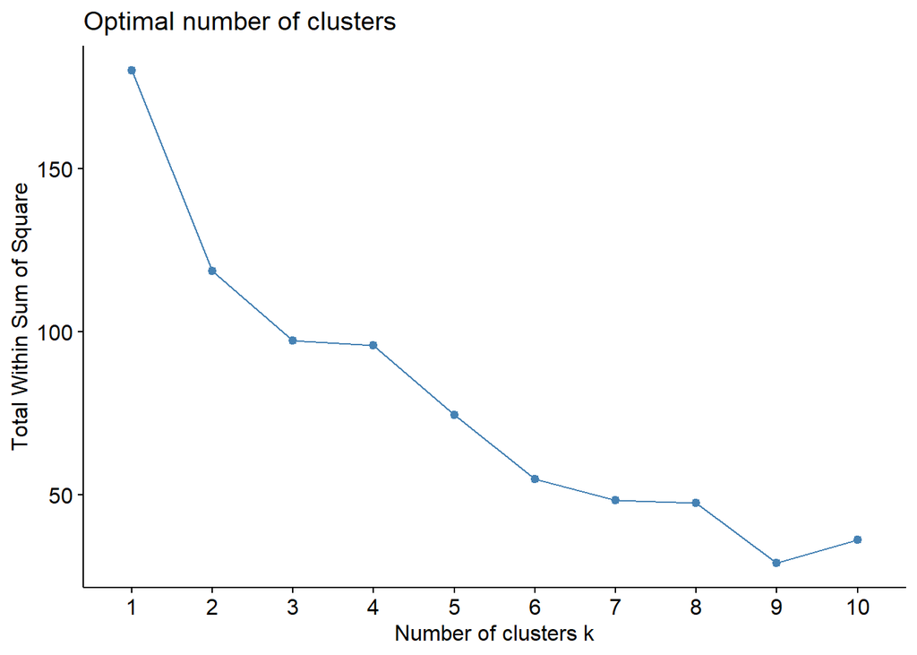

```r
fviz_nbclust(pharma_scaled, kmeans, method = "wss")
```

```r
set.seed(123)
pharma_k3 <- kmeans(pharma_scaled, centers = 3, nstart =25)
pharma_k3$centers
```

```
##   Market_Cap       Beta   PE_Ratio        ROE        ROA Asset_Turnover
## 1 -0.6125361  0.2698666  1.3143935 -0.9609057 -1.0174553      0.2306328
## 2  0.6733825 -0.3586419 -0.2763512  0.6565978  0.8344159      0.4612656
## 3 -0.8261772  0.4775991 -0.3696184 -0.5631589 -0.8514589     -0.9994088
##     Leverage Rev_Growth Net_Profit_Margin
## 1 -0.3592866 -0.5757385        -1.3784169
## 2 -0.3331068 -0.2902163         0.6823310
## 3  0.8502201  0.9158889        -0.3319956
```

```r
pharma_k3$size
```

```
## [1]  4 11  6
```

```r
pharma_k3$cluster
```

```
##  [1] 2 1 1 2 3 1 2 3 3 2 2 3 2 3 2 2 2 1 2 3 2
```

USED K MEANS TO GROUP THE 21 FIRMS BASED ON THE 9 VARIABLES… USED SCALE() BECAUSE OF SCALE DIFFERENCES BETWEEN VARIABLES AND USED ELBOW METHOD TO SELECT THE 3 CLUSTERS AND ALSO USE THE NSTART=25 LIKE I SAW IN THE CLASS SLIDES.

```r
pharma$Cluster <- pharma_k3$cluster
pharma[, c("Symbol", "Name", "Cluster")]
```

```
##    Symbol                               Name Cluster
## 1     ABT                Abbott Laboratories       2
## 2     AGN                     Allergan, Inc.       1
## 3     AHM                       Amersham plc       1
## 4     AZN                    AstraZeneca PLC       2
## 5     AVE                            Aventis       3
## 6     BAY                           Bayer AG       1
## 7     BMY       Bristol-Myers Squibb Company       2
## 8    CHTT                       Chattem, Inc       3
## 9     ELN              Elan Corporation, plc       3
## 10    LLY              Eli Lilly and Company       2
## 11    GSK                GlaxoSmithKline plc       2
## 12    IVX                   IVAX Corporation       3
## 13    JNJ                  Johnson & Johnson       2
## 14    MRX Medicis Pharmaceutical Corporation       3
## 15    MRK                  Merck & Co., Inc.       2
## 16    NVS                        Novartis AG       2
## 17    PFE                         Pfizer Inc       2
## 18    PHA              Pharmacia Corporation       1
## 19    SGP        Schering-Plough Corporation       2
## 20    WPI       Watson Pharmaceuticals, Inc.       3
## 21    WYE                              Wyeth       2
```

```r
View(pharma[, c("Symbol", "Name", "Cluster")])
```

cluster 1 has 4 firms it has firms that are below average market capitalization, ROE, ROA and NET PROFIT MARGIN. and they have above average P/E RATIO, BETA and ASSET TURNOVER… this cluster is the weaker one.

cluster 2 has 11 firms and is the bigger cluster… all the firms have above average market capitalization, ROE, ROA, and NET PROFIT MARGIN and have below average BETA, P/E RATIO. LEVERAGE and REVENUE GROWTH. this is a cluster has more profit and less risk

cluster 3 has 6 firms and they have below average marget capitalization, ROE, ROA, ASSET TURNOVER and NET PROFIT MARGIN. they have above average BETA, LEVERAGE, and REVENUE GROWTH. this group has smaller profit and high risk and good revenue growth.

```r
View(pharma[, c("Name", "Cluster",
                "Median_Recommendation",
                "Location", "Exchange")])
```

c

The clusters have some patterns i would say… cluster 2 contains many firms with HOLD M.recommendation but others have mixed M.recommendations. US firms shows in all 3 clusters as well as firms from other countries. a lot of the firms are listed on the NYSE, while NASDAQ and AMEX only show 1 time.

d

CLUSTER 1- SMALLER FIRM(LESS-PROFITABLE) CLUSTER 2- BIGGER FIRM(MORE-PROFITABLE) CLUSTER 3- REVENUE GROWTH FIRM(HIGH FINANCIAL RISK)